# EI-EP06-respuesta-equipo-4

2025-04-25

## Contexto

Un equipo de investigadores del área de interacción humano-información está estudiando si el área temática y el nivel de dificultad del problema de información influyen en el tiempo (en segundos) que toma un usuario en formular una consulta de búsqueda para resolver dicho problema. Para ello, han reclutado a un grupo de participantes voluntarios, asignados aleatoriamente a distintos grupos. Cada participante debe resolver tres problemas de información con diferentes niveles de dificultad: baja, media y alta. A su vez, cada grupo debe resolver problemas relacionados a una temática diferente. Los datos recolectados contemplan las siguientes variables:

| Variable | Descripción |
| --- | --- |
| `id` | Identificador único de cada participante. |
| `area` | Área temática de los problemas que el participante debe responder. Variable categórica con los niveles: Arquitectura, Biología, Computación, Economía, Física, Leyes, Literatura, Matemáticas, Música, P… |
| `dificultad` | Nivel de dificultad del problema resuelto. Variable categórica con los niveles: Baja, Media y Alta. |
| `tiempo` | Tiempo, en segundos, que toma al participante formular la consulta. |

## Pregunta

En este momento, los investigadores buscan determinar si existen diferencias en el tiempo que tardan los usuarios en formular consultas para problemas con diferente nivel de dificultad en el área de biología.

```r
library(tidyr)
library(dplyr)
library(ggplot2)
library(gridExtra)
library(ggpubr)
library(DescTools)
library(ez)
library(emmeans)
library(nlme)
```

En primera instancia, se filtran los datos para quedarnos solo con el área de biología y las variables `id`, `dificultad` y `tiempo`.

```r
# Carga de datos
datos <- read.csv("EP06 Datos.csv")

datos_seleccion <- datos %>% filter(area == "Biología") %>% select(id, dificultad, tiempo)

head(datos_seleccion)
```

```
##   id dificultad tiempo
## 1 27       Baja     90
## 2 27      Media     82
## 3 27       Alta     96
## 4 28       Baja     78
## 5 28      Media     86
## 6 28       Alta     95
```

Dado que se nos pide determinar si existen diferencias en los tiempos que tardan los usuarios en formular preguntas de acuerdo con la dificultad de los problemas, podemos identificar cuáles son las variables involucradas, que son las siguientes:

- **Variable dependiente:** Tiempo (en segundos) que toma un usuario en formular una consulta de búsqueda.
- **Variable independiente:** Nivel de dificultad del problema de información (bajo, medio, alto).

Se plantea la hipótesis nula y alternativa para el análisis de varianza (ANOVA) para muestras relacionadas considerando la dificultad del problema como factor y el tiempo como variable dependiente:

- **Hipótesis nula:** No hay diferencias significativas en el tiempo que tardan los usuarios en formular consultas para problemas con diferente nivel de dificultad en el área de biología.
- **Hipótesis alternativa:** Hay diferencias significativas en al menos uno de los tiempos que tardan los usuarios en formular consultas para problemas con diferente nivel de dificultad en el área de biología.

Esto matemáticamente se expresa como:

- $H_0: \mu_{Baja} = \mu_{Media} = \mu_{Alta}$
- $H_a$: $\exists\ i,j \in {Baja, Media, Alta} : \mu_i \neq \mu_j$

Para verificar el uso correcto del procedimiento ANOVA de una vía para muestras correlacionadas, se deben cumplir las siguientes condiciones:

1. La escala con que se mide la variable dependiente tiene las propiedades de una escala de intervalos iguales.
2. Las observaciones son independientes al interior de cada muestra.
3. Se puede suponer razonablemente que la(s) población(es) de origen sigue(n) una distribución normal.
4. La matriz de varianzas-covarianzas es esférica. Esta condición establece que las varianzas entre los diferentes niveles de las medidas repetidas deben ser iguales.
- **Condición 1:** Esta condición se cumple, ya que el tiempo es una variable continua y se mide en segundos. Incluso este cumple con una escala de razón lo que es más estricta que una escala de intervalos iguales.
- **Condición 2:** Esta condición se cumple, ya que del enunciado se identifica que las muestras son tomadas de manera aleatoria, además estas son independientes, pues el tiempo de formular una pregunta de una persona no depende de la otra.
- **Condición 3:** Esta condición se puede verificar mediante un gráfico Q-Q.

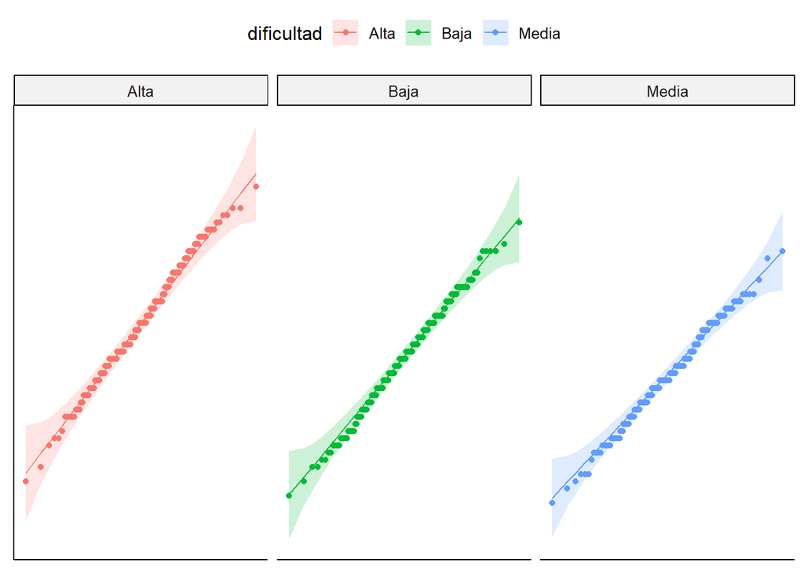

```r
g <- ggqqplot(datos_seleccion, x = "tiempo", y = "dificultad", color = "dificultad")

g <- g + facet_wrap(~ dificultad)
g <- g + rremove("x.ticks") + rremove("x.text")
g <- g + rremove("y.ticks") + rremove("y.text")
g <- g + rremove("axis.title")

print(g)
```

Los gráficos Q-Q muestran que los datos se distribuyen de manera normal, ya que todos los datos siguen el comportamiento esperado. Igualmente para confirmar se realizarán pruebas de normalidad de Shapiro-Wilk para cada uno de los grupos.

```r
dif_baja <- datos_seleccion |> filter(dificultad == "Baja") |> pull(tiempo)
dif_media <- datos_seleccion |> filter(dificultad == "Media") |> pull(tiempo)
dif_alta <- datos_seleccion |> filter(dificultad == "Alta") |> pull(tiempo)

shap_baja <- shapiro.test(dif_baja)
shap_media <- shapiro.test(dif_media)
shap_alta <- shapiro.test(dif_alta)

shap_baja
```

```
##
##  Shapiro-Wilk normality test
##
## data:  dif_baja
## W = 0.99526, p-value = 0.7877
```

```r
shap_media
```

```
##
##  Shapiro-Wilk normality test
##
## data:  dif_media
## W = 0.99334, p-value = 0.5055
```

```r
shap_alta
```

```
##
##  Shapiro-Wilk normality test
##
## data:  dif_alta
## W = 0.99422, p-value = 0.633
```

Dado los resultados obtenidos en las pruebas de Shapiro-Wilk y el análisis de los gráficos, podemos concluir con un 95% de confianza que los datos siguen una distribución normal, por lo que se cumplen todas las condiciones para una prueba ANOVA.

- **Condición 4:** La esfericidad se verificará mediante la prueba de Mauchly.

```r
# Convertir la variable 'dificultad' a un factor
datos_seleccion$dificultad <- as.factor(datos_seleccion$dificultad)
datos_seleccion$id <- as.factor(datos_seleccion$id)


# Realizar el ANOVA de una vía para muestras correlacionadas
anova_result <- ezANOVA(
  data = datos_seleccion,
  dv = tiempo,
  wid = id,
  within = dificultad,
)

print(anova_result)
```

```
## $ANOVA
##       Effect DFn DFd        F            p p<.05       ges
## 2 dificultad   2 398 59.26425 2.957803e-23     * 0.1619409
##
## $`Mauchly's Test for Sphericity`
##       Effect         W         p p<.05
## 2 dificultad 0.9935213 0.5254602
##
## $`Sphericity Corrections`
##       Effect      GGe        p[GG] p[GG]<.05      HFe        p[HF] p[HF]<.05
## 2 dificultad 0.993563 4.014602e-23         * 1.003552 2.957803e-23         *
```

En la prueba de esfericidad de Mauchly se obtuvo un valor p de 0.5254602, el cual es mayor al nivel de significancia de 0.05; por ende, no se rechaza la hipótesis nula de esfericidad y no es necesario realizar correcciones. Con ello podemos analizar los resultados del ANOVA de una vía para muestras correlacionadas.

Como se puede observar, el valor p obtenido 2.957803e-23 resulta ser menor al nivel de significancia de 0.05 como consecuencia, se rechaza la hipótesis nula, en otras palabras, existen diferencias significativas en al menos uno de los tiempos que tardan los usuarios en formular consultas para problemas con diferente nivel de dificultad en el área de biología.

#### Procedimiento Post-Hoc

Dado que se rechazó la hipótesis nula en favor a la alternativa, es recomendable aplicar un procedimiento post-hoc para determinar cuáles son los niveles de dificultad que difieren entre sí. Dado que antes se verificaron las condiciones de ANOVA de una vía para muestras correlacionadas, se puede aplicar el test de Tukey, que es un procedimiento post-hoc que permite comparar todas las medias de los grupos entre sí y determinar cuáles son significativamente diferente, pues en este caso particular no es necesario hacer contrastes adicionales más allá de los planteados.

```r
# Modelo Lineal Mixto
lme_model <- lme(tiempo ~ dificultad, data = datos_seleccion, random = ~ 1 | id)

# Estimar Medias Marginales
emmeans_result <- emmeans(lme_model, ~ dificultad)

post_hoc <- contrast(emmeans_result, "pairwise", adjust = "tukey")

post_hoc
```

```
##  contrast     estimate    SE  df t.ratio p.value
##  Alta - Baja      4.88 0.699 398   6.993  <.0001
##  Alta - Media     7.49 0.699 398  10.723  <.0001
##  Baja - Media     2.60 0.699 398   3.729  0.0006
##
## Degrees-of-freedom method: containment
## P value adjustment: tukey method for comparing a family of 3 estimates
```